# Data visualization using R base graphics

### Text and Symbol Size

The following options can be used to control text and symbol size in graphs.

| Option | Description |
| --- | --- |
| cex | number indicating the amount by which plotting text and symbols should be scaled relative to the default. 1=default, 1.5 is 50% larger, 0.5 is 50% smaller, etc. |
| cex.axis | magnification of axis annotation relative to cex |
| cex.lab | magnification of x and y labels relative to cex |
| cex.main | magnification of titles relative to cex |
| cex.sub | magnification of subtitles relative to cex |

### Plotting Symbols

Use the pch= option to specify symbols to use when plotting points. For symbols 21 through 25, specify border color (col=) and fill color (bg=).

### Lines

You can change lines using the following options. This is particularly useful for reference lines, axes, and fit lines.

| Option | Description |
| --- | --- |
| lty | line type. see the chart below. |
| lwd | line width relative to the default (default=1). 2 is twice as wide. |

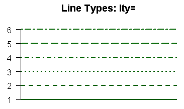

### Colors

Options that specify colors include the following.

| Option | Description |
| --- | --- |
| col | Default plotting color. Some functions (e.g. lines) accept a vector of values that are recycled. |
| col.axis | color for axis annotation |
| col.lab | color for x and y labels |
| col.main | color for titles |
| col.sub | color for subtitles |
| fg | plot foreground color (axes, boxes - also sets col= to same) |
| bg | plot background color |

You can specify colors in R by index, name, hexadecimal, or RGB. For example col=1, col=“white”, and col=“#FFFFFF” are equivalent.

The following chart was produced with code developed by Earl F. Glynn. For more options, see this [cheat sheet](https://www.nceas.ucsb.edu/~frazier/RSpatialGuides/colorPaletteCheatsheet.pdf).

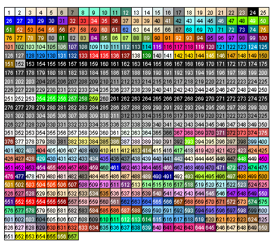

You can also create a vector of n contiguous colors using the functions rainbow(n), heat.colors(n), terrain.colors(n), topo.colors(n), and cm.colors(n).

colors() returns all available color names.

### Fonts

You can easily set font size and style, but font family is a bit more complicated.

| Option | Description |
| --- | --- |
| font | Integer specifying font to use for text. 1=plain, 2=bold, 3=italic, 4=bold italic, 5=symbol |
| font.axis | font for axis annotation |
| font.lab | font for x and y labels |
| font.main | font for titles |
| font.sub | font for subtitles |
| ps | font point size (roughly 1/72 inch) |
| text size=ps*cex |  |
| family | font family for drawing text. Standard values are “serif”, “sans”, “mono”, “symbol”. |

Font mapping is device dependent.  
In windows, mono is mapped to “TT Courier New”, serif is mapped to“TT Times New Roman”, sans is mapped to “TT Arial”, mono is mapped to “TT Courier New”, and symbol is mapped to “TT Symbol” (TT=True Type). You can add your own mappings.

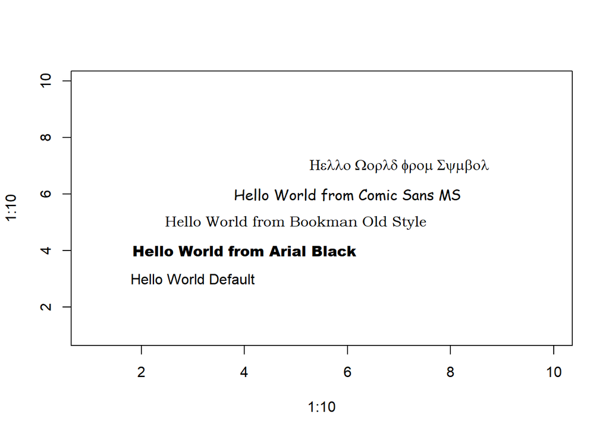

```r
# Type family examples - creating new mappings
plot(1:10, 1:10, type = "n")
windowsFonts(
  A = windowsFont("Arial Black"),
  B = windowsFont("Bookman Old Style"),
  C = windowsFont("Comic Sans MS"),
  D = windowsFont("Symbol")
)
text(3, 3, "Hello World Default")
text(4, 4, family = "A", "Hello World from Arial Black")
text(5, 5, family = "B", "Hello World from Bookman Old Style")
text(6, 6, family = "C", "Hello World from Comic Sans MS")
text(7, 7, family = "D", "Hello World from Symbol")
```

### Margins and Graph Size

You can control the margin size using the following parameters.

| Option | Description |
| --- | --- |
| mar | numerical vector indicating margin size c(bottom, left, top, right) in lines. default = c(5, 4, 4, 2) + 0.1 |
| mai | numerical vector indicating margin size c(bottom, left, top, right) in inches |
| pin | plot dimensions (width, height) in inches |

For complete information on margins, See the diagram below:

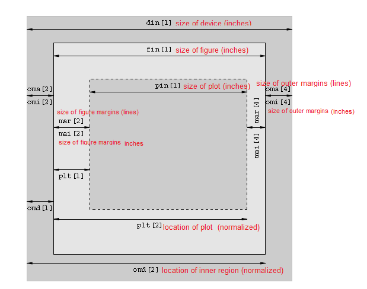

### Axes and Text

Many high level plotting functions (plot, hist, boxplot, etc.) allow you to include axis and text options (as well as other graphical parameters). For example

```r
# not run
# Specify axis options within plot()
plot(
  x,
  y,
  main = "title",
  sub = "subtitle",
  xlab = "X-axis label",
  ylab = "y-axix label",
  xlim = c(xmin, xmax),
  ylim = c(ymin, ymax)
)
```

For finer control or for modularization, you can use the functions described below.

#### Titles

Use the title( ) function to add labels to a plot.

```r
# not run
title(
  main = "main title",
  sub = "sub-title",
  xlab = "x-axis label",
  ylab = "y-axis label"
)
```

Many other graphical parameters (such as text size, font, rotation, and color) can also be specified in the title( ) function.

```r
# not run
# Add a red title and a blue subtitle. Make x and y
# labels 25% smaller than the default and green.
title(
  main = "My Title",
  col.main = "red",
  sub = "My Sub-title",
  col.sub = "blue",
  xlab = "My X label",
  ylab = "My Y label",
  col.lab = "green",
  cex.lab = 0.75
)
```

#### Text Annotations

Text can be added to graphs using the text( ) and mtext( ) functions. text( ) places text within the graph while mtext( ) places text in one of the four margins.

```r
# not run
text(location, "text to place", pos, ...)
mtext("text to place", side, line = n, ...)
```

Common options are described below.

[output not shown]

Other common options are cex, col, and font (for size, color, and font style respectively).

#### Labeling points

You can use the text( ) function (see above) for labeling point as well as for adding other text annotations. Specify location as a set of x, y coordinates and specify the text to place as a vector of labels. The x, y, and label vectors should all be the same length.

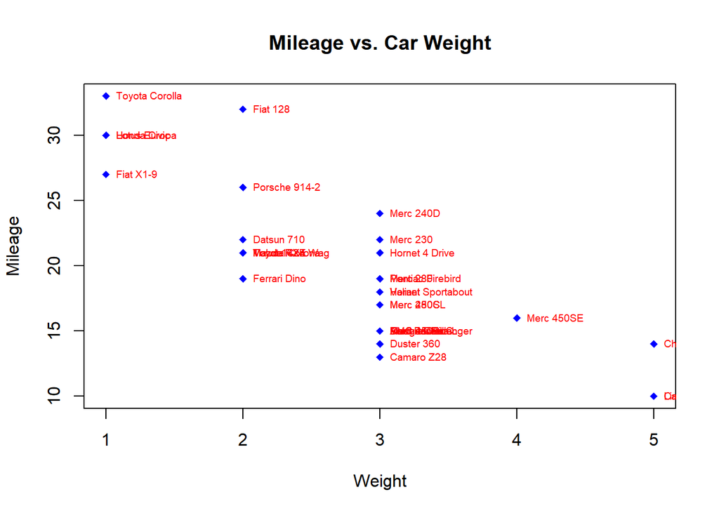

```r
# Example of labeling points
plot(
  wt,
  mpg,
  main = "Mileage vs. Car Weight",
  xlab = "Weight",
  ylab = "Mileage",
  pch = 18,
  col = "blue"
)
text(
  wt,
  mpg,
  row.names(mtcars),
  cex = 0.6,
  pos = 4,
  col = "red"
)
```

#### Math Annotations

You can add mathematically formulas to a graph using TEX-like rules. See help(plotmath) for details and examples.

#### Axes

You can create custom axes using the axis( ) function.

```r
# not run
axis(side, at=, labels=, pos=, lty=, col=, las=, tck=, ...)
```

where

| Option | Description |
| --- | --- |
| side | an integer indicating the side of the graph to draw the axis (1=bottom, 2=left, 3=top, 4=right) |
| at | a numeric vector indicating where tic marks should be drawn |
| labels | a character vector of labels to be placed at the tickmarks (if NULL, the at values will be used) |
| pos | the coordinate at which the axis line is to be drawn. (i.e., the value on the other axis where it crosses) |
| lty | line type |
| col | the line and tick mark color |
| las | labels are parallel (=0) or perpendicular(=2) to axis |
| tck | length of tick mark as fraction of plotting region (negative number is outside graph, positive number is inside, 0 suppresses ticks, 1 creates gridlines) default is -0.01 |
| … | other graphical parameters |

If you are going to create a custom axis, you should suppress the axis automatically generated by your high level plotting function. The option axes=FALSE suppresses both x and y axes. xaxt=“n” and yaxt=“n” suppress the x and y axis respectively. Here is a (somewhat overblown) example.

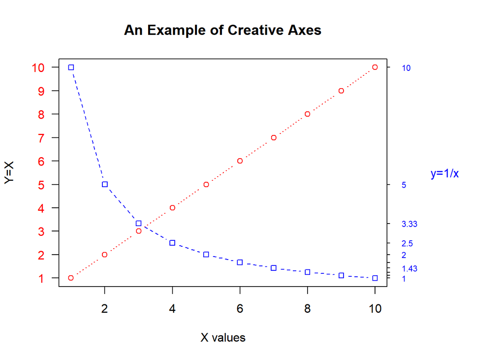

```r
# A Silly Axis Example

# specify the data
x <- c(1:10)
y <- x
z <- 10 / x

# create extra margin room on the right for an axis
par(mar = c(5, 4, 4, 8) + 0.1)

# plot x vs. y
plot(
  x,
  y,
  type = "b",
  pch = 21,
  col = "red",
  yaxt = "n",
  lty = 3,
  xlab = "",
  ylab = ""
)

# add x vs. 1/x
lines(
  x,
  z,
  type = "b",
  pch = 22,
  col = "blue",
  lty = 2
)

# draw an axis on the left
axis(
  2,
  at = x,
  labels = x,
  col.axis = "red",
  las = 2
)

# draw an axis on the right, with smaller text and ticks
axis(
  4,
  at = z,
  labels = round(z, digits = 2),
  col.axis = "blue",
  las = 2,
  cex.axis = 0.7,
  tck = -.01
)

# add a title for the right axis
mtext(
  "y=1/x",
  side = 4,
  line = 3,
  cex.lab = 1,
  las = 2,
  col = "blue"
)

# add a main title and bottom and left axis labels
title("An Example of Creative Axes", xlab = "X values",
      ylab = "Y=X")
```

#### Minor Tick Marks

The minor.tick( ) function in the Hmisc package adds minor tick marks.

```r
# not run
# Add minor tick marks
library(Hmisc)
minor.tick(nx = n,
           ny = n,
           tick.ratio = n)
```

nx is the number of minor tick marks to place between x-axis major tick marks. ny does the same for the y-axis. tick.ratio is the size of the minor tick mark relative to the major tick mark. The length of the major tick mark is retrieved from par(“tck”).

#### Reference Lines

Add reference lines to a graph using the abline( ) function.

```r
# not run
abline(h = yvalues, v = xvalues)
```

Other graphical parameters (such as line type, color, and width) can also be specified in the abline( ) function.

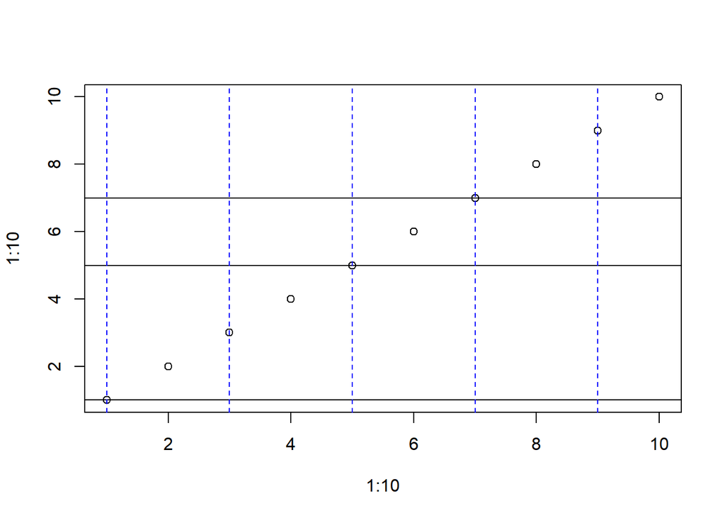

```r
# add solid horizontal lines at y=1,5,7
plot(x = 1:10, y = 1:10, type = "p")
abline(h = c(1,5,7))
# add dashed blue verical lines at x = 1,3,5,7,9
abline(v = seq(1,10,2),lty = 2,col = "blue")
```

Note: You can also use the grid( ) function to add reference lines.

#### Legend

Add a legend with the legend() function.

```r
# not run
legend(location, title, legend, ...)
```

Common options are described below.

[output not shown]

Other common legend options include bty for box type, bg for background color, cex for size, and text.col for text color. Setting horiz=TRUE sets the legend horizontally rather than vertically.

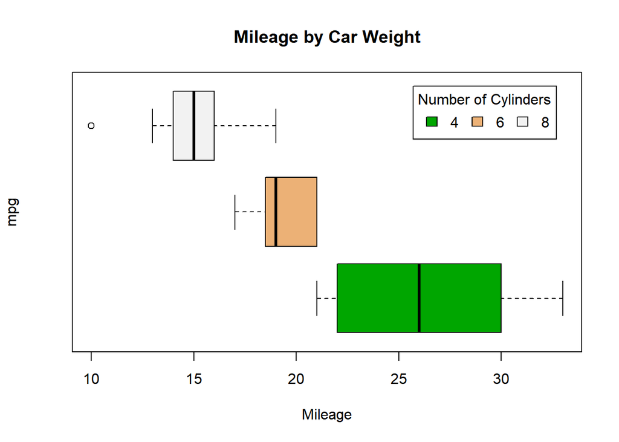

```r
# Legend Example
boxplot(
  mpg ~ cyl,
  main = "Mileage by Car Weight",
  yaxt = "n",
  xlab = "Mileage",
  horizontal = TRUE,
  col = terrain.colors(3)
)
legend(
  "topright",
  inset = .05,
  title = "Number of Cylinders",
  c("4", "6", "8"),
  fill = terrain.colors(3),
  horiz = TRUE
)
```

## Combining Plots

R makes it easy to combine multiple plots into one overall graph, using either the par( ) or layout( ) function.

With the par( ) function, you can include the option mfrow=c(nrows, ncols) to create a matrix of nrows x ncols plots that are filled in by row. mfcol=c(nrows, ncols) fills in the matrix by columns.

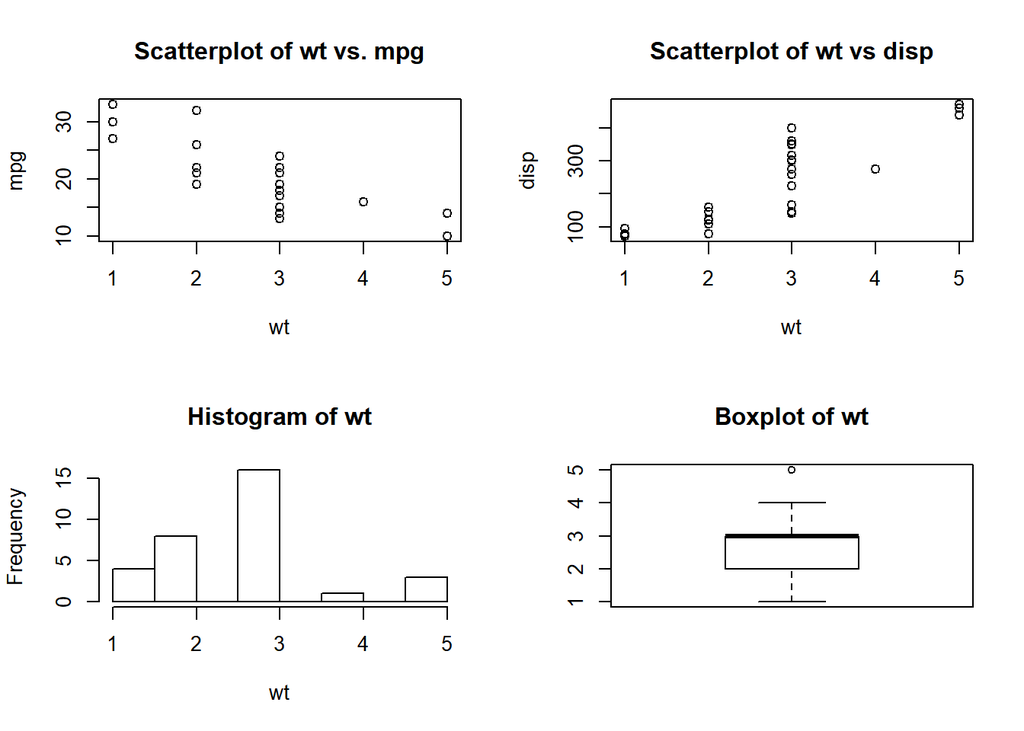

```r
# 4 figures arranged in 2 rows and 2 columns
par(mfrow = c(2, 2))
plot(wt, mpg, main = "Scatterplot of wt vs. mpg")
plot(wt, disp, main = "Scatterplot of wt vs disp")
hist(wt, main = "Histogram of wt")
boxplot(wt, main = "Boxplot of wt")
```

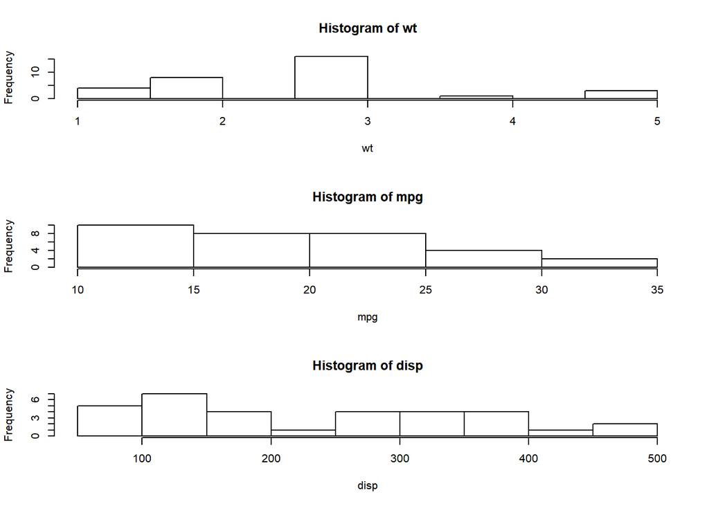

```r
# 3 figures arranged in 3 rows and 1 column
par(mfrow = c(3, 1))
hist(wt)
hist(mpg)
hist(disp)
```

The layout( ) function has the form layout(mat) where mat is a matrix object specifying the location of the N figures to plot.

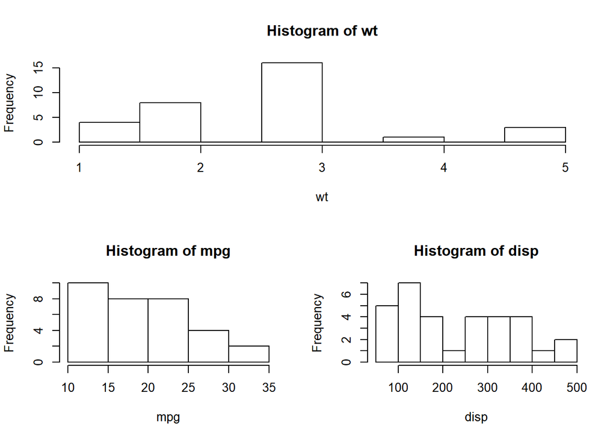

```r
# One figure in row 1 and two figures in row 2
layout(matrix(c(1,1,2,3), 2, 2, byrow = TRUE))
hist(wt)
hist(mpg)
hist(disp)
```

Optionally, you can include widths= and heights= options in the layout( ) function to control the size of each figure more precisely. These options have the form:  
widths: a vector of values for the widths of columns heights:a vector of values for the heights of rows.